# Employee Attrition Prediction with Sentiment Analysis

Le Zhang, Data Scientist, Microsoft

2017-08-21

## 1 Introduction

Voluntary employee attrition may negatively affect a company in various aspects, i.e., induce labor cost, lose morality of employees, leak IP/talents to competitors, etc. Identifying individual employee with inclination of leaving company is therefore pivotal to save the potential loss. Conventional practices rely on qualitative assessment on factors that may reflect the propensity of an employee to leave company. For example, studies found that staff churn is correlated with both demographic information as well as behavioral activities, satisfaction, etc. Data-driven techniques which are based on statistical learning methods exhibit more accurate prediction on employee attrition, as by nature they mathematically model the correlation between factors and attrition outcome and maximize the probability of predicting the correct group of people with a properly trained machine learning model.

In the data-driven employee attrition prediction model, normally two types of data are taken into consideration.

1. First type refers to the demographic and organizational information of an employee such as *age*, *gender*, *title*, etc. The characteristics of this group of data is that **within a certain interval, they don’t change or solely increment deterministically over time**. For example, gender will never change for an individual, and other factors such as *years of service* increments every year.
2. Second type of data is the dynamically involving information about an employee. Recent [studies](http://www.wsj.com/articles/how-do-employees-really-feel-about-their-companies-1444788408) report that *sentiment* is playing a critical role in employee attrition prediction. Classical measures of sentiment include *job satisfaction*, *environment satisfaction*, *relationship satisfaction*, etc. With the machine learning techniques, sentiment patterns can be exploited from daily activities such as text posts on social media for predicting churn inclination.

## 2 Data-driven analytics for HR attrition prediction

```r
# data wrangling
library(dplyr)
library(magrittr)
library(stringr)
library(stringi)
library(readr)
# machine learning and advanced analytics
library(DMwR)
library(caret)
library(caretEnsemble)
library(pROC)
# natural language processing
library(msLanguageR)
library(tm)
library(jiebaR)
# tools
library(httr)
library(XML)
library(jsonlite)
# data visualization
library(scales)
library(ggplot2)
library(wordcloud)
```

```r
# some global variables
DATA1 <- "../Data/DataSet1.csv"
DATA2 <- "../Data/DataSet2.csv"
```

### 2.1 Demographic and organizational data

The experiments will be conducted on a data set of employees. The data set is publicly available and can be found at [here](https://www.ibm.com/communities/analytics/watson-analytics-blog/hr-employee-attrition/).

#### 2.1.1 Data exploration

```r
df <- read_csv(DATA1)
```

```r
head(df)
```

| Age | Attrition | BusinessTravel | DailyRate | Department | DistanceFromHome | Education | EducationField | EmployeeCount | EnvironmentSatisfaction | Gender | HourlyRate | JobInvolvement | JobLevel | JobRole | JobSatisfaction | MaritalStatus | MonthlyIncome | MonthlyRate | NumCompaniesWorked | OverTime | PercentSalaryHike | PerformanceRating | RelationshipSatisfaction | StandardHours | StockOptionLevel | TotalWorkingYears | TrainingTimesLastYear | WorkLifeBalance | YearsAtCompany | … |
| --- | --- | --- | --- | --- | --- | --- | --- | --- | --- | --- | --- | --- | --- | --- | --- | --- | --- | --- | --- | --- | --- | --- | --- | --- | --- | --- | --- | --- | --- | --- |
| 49 | No | Travel_Frequently | 279 | Research & Development | 8 | 1 | Life Sciences | 1 | 3 | Male | 61 | 2 | 2 | Research Scientist | 2 | Married | 5130 | 24907 | 1 | No | 23 | 4 | 4 | 80 | 1 | 10 | 3 | 3 | 10 | … |
| 33 | No | Travel_Frequently | 1392 | Research & Development | 3 | 4 | Life Sciences | 1 | 4 | Female | 56 | 3 | 1 | Research Scientist | 3 | Married | 2909 | 23159 | 1 | Yes | 11 | 3 | 3 | 80 | 0 | 8 | 3 | 3 | 8 | … |
| 27 | No | Travel_Rarely | 591 | Research & Development | 2 | 1 | Medical | 1 | 1 | Male | 40 | 3 | 1 | Laboratory Technician | 2 | Married | 3468 | 16632 | 9 | No | 12 | 3 | 4 | 80 | 1 | 6 | 3 | 3 | 2 | … |
| 32 | No | Travel_Frequently | 1005 | Research & Development | 2 | 2 | Life Sciences | 1 | 4 | Male | 79 | 3 | 1 | Laboratory Technician | 4 | Single | 3068 | 11864 | 0 | No | 13 | 3 | 3 | 80 | 0 | 8 | 2 | 2 | 7 | … |
| 59 | No | Travel_Rarely | 1324 | Research & Development | 3 | 3 | Medical | 1 | 3 | Female | 81 | 4 | 1 | Laboratory Technician | 1 | Married | 2670 | 9964 | 4 | Yes | 20 | 4 | 1 | 80 | 3 | 12 | 3 | 2 | 1 | … |
| 30 | No | Travel_Rarely | 1358 | Research & Development | 24 | 1 | Life Sciences | 1 | 4 | Male | 67 | 3 | 1 | Laboratory Technician | 3 | Divorced | 2693 | 13335 | 1 | No | 22 | 4 | 2 | 80 | 1 | 1 | 2 | 3 | 1 | … |

```r
dim(df)
```

```
[1] 1470   33
```

```r
names(df)
```

```
 [1] "Age"                      "Attrition"                "BusinessTravel"
 [4] "DailyRate"                "Department"               "DistanceFromHome"
 [7] "Education"                "EducationField"           "EmployeeCount"
[10] "EnvironmentSatisfaction"  "Gender"                   "HourlyRate"
[13] "JobInvolvement"           "JobLevel"                 "JobRole"
[16] "JobSatisfaction"          "MaritalStatus"            "MonthlyIncome"
[19] "MonthlyRate"              "NumCompaniesWorked"       "OverTime"
[22] "PercentSalaryHike"        "PerformanceRating"        "RelationshipSatisfaction"
[25] "StandardHours"            "StockOptionLevel"         "TotalWorkingYears"
[28] "TrainingTimesLastYear"    "WorkLifeBalance"          "YearsAtCompany"
[31] "YearsInCurrentRole"       "YearsSinceLastPromotion"  "YearsWithCurrManager"
```

```r
str(df)
```

```
Classes â€˜tbl_dfâ€™, â€˜tblâ€™ and 'data.frame':   1470 obs. of  33 variables:
 $ Age                     : int  49 33 27 32 59 30 38 36 35 29 ...
 $ Attrition               : chr  "No" "No" "No" "No" ...
 $ BusinessTravel          : chr  "Travel_Frequently" "Travel_Frequently" "Travel_Rarely" "Travel_Frequently" ...
 $ DailyRate               : int  279 1392 591 1005 1324 1358 216 1299 809 153 ...
 $ Department              : chr  "Research & Development" "Research & Development" "Research & Development" "Research & Development" ...
 $ DistanceFromHome        : int  8 3 2 2 3 24 23 27 16 15 ...
 $ Education               : int  1 4 1 2 3 1 3 3 3 2 ...
 $ EducationField          : chr  "Life Sciences" "Life Sciences" "Medical" "Life Sciences" ...
 $ EmployeeCount           : int  1 1 1 1 1 1 1 1 1 1 ...
 $ EnvironmentSatisfaction : int  3 4 1 4 3 4 4 3 1 4 ...
 $ Gender                  : chr  "Male" "Female" "Male" "Male" ...
 $ HourlyRate              : int  61 56 40 79 81 67 44 94 84 49 ...
 $ JobInvolvement          : int  2 3 3 3 4 3 2 3 4 2 ...
 $ JobLevel                : int  2 1 1 1 1 1 3 2 1 2 ...
```

[output cut: 19 more lines]

#### 2.1.2 Visualization of data

Initial exploratory analysis can be performed to understand the data set. For example,

1. the proportion of employees with different job titles (or any other possible factor) for status of “attrition” and “non-attrition” may vary, and this can be plotted as follows. People titled “Laboratory Technician”, “Sales Executive”, and “Research Scientist” are among the top 3 groups that exhibit highest attrition rate.

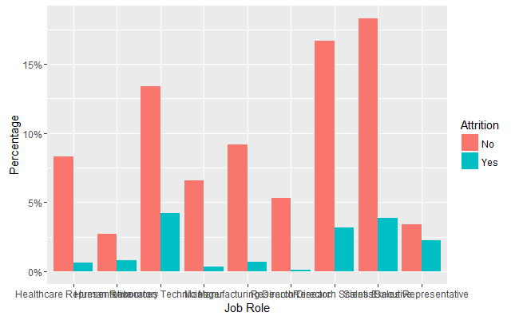

```r
ggplot(df, aes(JobRole, fill=Attrition)) +
  geom_bar(aes(y=(..count..)/sum(..count..)), position="dodge") +
  scale_y_continuous(labels=percent) +
  xlab("Job Role") +
  ylab("Percentage")
```

2. monthly income, job level, and service year may affect decision of leaving for employees in different departments. For example, junior staffs with lower pay will be more likely to leave compared to those who are paid higher.

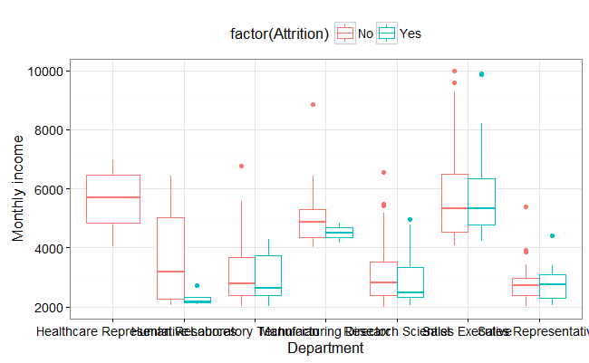

```r
ggplot(filter(df, (YearsAtCompany >= 2) & (YearsAtCompany <= 5) & (JobLevel < 3)),
       aes(x=factor(JobRole), y=MonthlyIncome, color=factor(Attrition))) +
  geom_boxplot() +
  xlab("Department") +
  ylab("Monthly income") +
  scale_fill_discrete(guide=guide_legend(title="Attrition")) +
  theme_bw() +
  theme(text=element_text(size=13), legend.position="top")
```

3. Promotion is a commonly adopted HR strategy for employee retention. It can be observed in the following plot that for a certain department, e.g., Research & Development, employees with higher job level is more likely to leave if there are years since their last promotion.

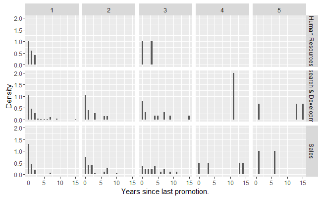

```r
ggplot(filter(df, as.character(Attrition) == "Yes"), aes(x=YearsSinceLastPromotion)) +
  geom_histogram(binwidth=0.5) +
  aes(y=..density..) +
  xlab("Years since last promotion.") +
  ylab("Density") +
  # scale_fill_discrete(guide=guide_legend(title="Attrition")) +
  facet_grid(Department ~ JobLevel)
```

#### 2.1.3 Data pre-processing

To perform further advanced analysis on the data set, initial pre-processing is necessary.

```r
# get predictors that has no variation.
pred_no_var <- names(df[, nearZeroVar(df)]) %T>% print()
```

```
[1] "EmployeeCount" "StandardHours"
```

```r
# remove the zero variation predictor columns.
df %<>% select(-one_of(pred_no_var))
```

Integer types of predictors which are nominal are converted to categorical type.

```r
# convert certain integer variable to factor variable.
int_2_ftr_vars <- c("Education", "EnvironmentSatisfaction", "JobInvolvement", "JobLevel", "JobSatisfaction", "NumCompaniesWorked", "PerformanceRating", "RelationshipSatisfaction", "StockOptionLevel")
df[, int_2_ftr_vars] <- lapply((df[, int_2_ftr_vars]), as.factor)
```

The variables of character type are converted to categorical type.

```r
df %<>% mutate_if(is.character, as.factor)
```

Take a look at the new data set.

```r
str(df)
```

```
Classes â€˜tbl_dfâ€™, â€˜tblâ€™ and 'data.frame':   1470 obs. of  31 variables:
 $ Age                     : int  49 33 27 32 59 30 38 36 35 29 ...
 $ Attrition               : Factor w/ 2 levels "No","Yes": 1 1 1 1 1 1 1 1 1 1 ...
 $ BusinessTravel          : Factor w/ 3 levels "Non-Travel","Travel_Frequently",..: 2 2 3 2 3 3 2 3 3 3 ...
 $ DailyRate               : int  279 1392 591 1005 1324 1358 216 1299 809 153 ...
 $ Department              : Factor w/ 3 levels "Human Resources",..: 2 2 2 2 2 2 2 2 2 2 ...
 $ DistanceFromHome        : int  8 3 2 2 3 24 23 27 16 15 ...
 $ Education               : Factor w/ 5 levels "1","2","3","4",..: 1 4 1 2 3 1 3 3 3 2 ...
 $ EducationField          : Factor w/ 6 levels "Human Resources",..: 2 2 4 2 4 2 2 4 4 2 ...
 $ EnvironmentSatisfaction : Factor w/ 4 levels "1","2","3","4": 3 4 1 4 3 4 4 3 1 4 ...
 $ Gender                  : Factor w/ 2 levels "Female","Male": 2 1 2 2 1 2 2 2 2 1 ...
 $ HourlyRate              : int  61 56 40 79 81 67 44 94 84 49 ...
 $ JobInvolvement          : Factor w/ 4 levels "1","2","3","4": 2 3 3 3 4 3 2 3 4 2 ...
 $ JobLevel                : Factor w/ 5 levels "1","2","3","4",..: 2 1 1 1 1 1 3 2 1 2 ...
 $ JobRole                 : Factor w/ 9 levels "Healthcare Representative",..: 7 7 3 3 3 3 5 1 3 3 ...
```

[output cut: 17 more lines]

#### 2.1.4 Problem formalization

After the data is well prepared, a model can be constructed for attrition prediction. Normally employee attrition prediction is categorized as a binary classification problem, i.e., to predict *whether or not an employee will leave*.

In this study case, the label for prediction is employee status, named as `Attrition` in the data set, which has two levels, `Yes` and `No`, indicating that the employee has left or stayed.

Check the label column to make sure it is a factor type, as the model to be built is a classifier.

```r
is.factor(df$Attrition)
```

```
[1] TRUE
```

#### 2.1.5 Feature selection

It is possible that not all variables are correlated with the label, feature selection is therefore performed to filter out the most relevant ones.

As the data set is a blend of both numerical and discrete variables, certain correlation analysis (e.g., Pearson correlation) is not applicable. One alternative is to train a model and then rank the variable importance so as to select the most salient ones.

The following shows how to achieve variable importance ranking with a random forest model.

```r
# set up the training control.
control <- trainControl(method="repeatedcv", number=3, repeats=1)
# train the model
model <- train(dplyr::select(df, -Attrition),
               df$Attrition,
               data=df,
               method="rf",
               preProcess="scale",
               trControl=control)
```

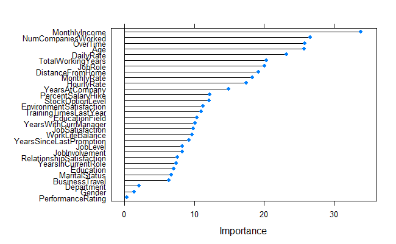

```r
# estimate variable importance
imp <- varImp(model, scale=FALSE)
# plot
plot(imp)
```

```r
# select the top-ranking variables.
imp_list <- rownames(imp$importance)[order(imp$importance$Overall, decreasing=TRUE)]
# drop the low ranking variables. Here the last 3 variables are dropped.
top_var <-
  imp_list[1:(length(imp_list) - 3)] %>%
  as.character()
top_var
```

```
 [1] "MonthlyIncome"            "NumCompaniesWorked"       "OverTime"
 [4] "Age"                      "DailyRate"                "TotalWorkingYears"
 [7] "JobRole"                  "DistanceFromHome"         "MonthlyRate"
[10] "HourlyRate"               "YearsAtCompany"           "PercentSalaryHike"
[13] "StockOptionLevel"         "EnvironmentSatisfaction"  "TrainingTimesLastYear"
[16] "EducationField"           "YearsWithCurrManager"     "JobSatisfaction"
[19] "WorkLifeBalance"          "YearsSinceLastPromotion"  "JobLevel"
[22] "JobInvolvement"           "RelationshipSatisfaction" "YearsInCurrentRole"
[25] "Education"                "MaritalStatus"            "BusinessTravel"
```

```r
# select the top ranking variables
df %<>% select(., one_of(c(top_var, "Attrition")))
```

#### 2.1.6 Resampling

A prediction model can be then created for predictive analysis. The whole data is split into training and testing sets. The former is used for model creation while the latter for verification.

```r
train_index <-
  createDataPartition(df$Attrition,
                      times=1,
                      p=.7) %>%
  unlist()
df_train <- df[train_index, ]
df_test <- df[-train_index, ]
```

One thing worthnoting is that the training set is not balanced, which may deteriorate the performance in training a model.

```r
table(df_train$Attrition)
```

```
 No Yes
864 166
```

Active employees (864) are more than terminated employees (166). There are several ways to deal with data imbalance issue:

1. Resampling the data - either upsampling the minority class or downsampling the majority class.
2. Use cost sensitive learning method.

In this case the first method is used. SMOTE is a commonly adopted method for synthetically upsampling minority class in an imbalanced data set. Package `DMwR` provides methods that apply SMOTE methods on training data set.

```r
# note DMwR::SMOTE does not handle well with tbl_df. Need to convert to data frame.
df_train %<>% as.data.frame()
df_train <- SMOTE(Attrition ~ .,
                  df_train,
                  perc.over=300,
                  perc.under=150)
```

```r
table(df_train$Attrition)
```

```
 No Yes
747 664
```

#### 2.1.7 Model building

After balancing the training set, a model can be created for prediction. For comparison purpose, different individual models, as well as ensemble of them, are trained on the data set. `caret` and `caretEnsemble` packages are used for training models.

1. Individual models. Three algorithms, support vector machine with radial basis function kernel, random forest, and extreme gradient boosting (xgboost), are used for model building.

```r
# initialize training control.
tc <- trainControl(method="boot",
                   number=3,
                   repeats=3,
                   search="grid",
                   classProbs=TRUE,
                   savePredictions="final",
                   summaryFunction=twoClassSummary)
# SVM model.
time_svm <- system.time(
  model_svm <- train(Attrition ~ .,
                     df_train,
                     method="svmRadial",
                     trainControl=tc)
)
# random forest model
time_rf <- system.time(
  model_rf <- train(Attrition ~ .,
                     df_train,
                     method="rf",
                     trainControl=tc)
)
# xgboost model.
time_xgb <- system.time(
  model_xgb <- train(Attrition ~ .,
                     df_train,
                     method="xgbLinear",
                     trainControl=tc)
)
```

2. Ensemble of models. Model ensemble is also created for comparative studies on performance. Here a stacking ensemble is demonstrated.

```r
# ensemble of the three models.
time_ensemble <- system.time(
  model_list <- caretList(Attrition ~ .,
                          data=df_train,
                          trControl=tc,
                          methodList=c("svmRadial", "rf", "xgbLinear"))
)
```

```r
# stack of models. Use glm for meta model.
model_stack <- caretStack(
  model_list,
  metric="ROC",
  method="glm",
  trControl=trainControl(
    method="boot",
    number=10,
    savePredictions="final",
    classProbs=TRUE,
    summaryFunction=twoClassSummary
  )
)
```

#### 2.1.8 Model validation

The trained models are applied on testing data sets for model evaluation.

```r
models <- list(model_svm, model_rf, model_xgb, model_stack)
predictions <-lapply(models,
                     predict,
                     newdata=select(df_test, -Attrition))
```

```r
# confusion matrix evaluation results.
cm_metrics <- lapply(predictions,
                     confusionMatrix,
                     reference=df_test$Attrition,
                     positive="Yes")
```

The results can be then comparatively studied.

```r
# accuracy
acc_metrics <-
  lapply(cm_metrics, `[[`, "overall") %>%
  lapply(`[`, 1) %>%
  unlist()
# recall
rec_metrics <-
  lapply(cm_metrics, `[[`, "byClass") %>%
  lapply(`[`, 1) %>%
  unlist()

# precision
pre_metrics <-
  lapply(cm_metrics, `[[`, "byClass") %>%
  lapply(`[`, 3) %>%
  unlist()
algo_list <- c("SVM RBF", "Random Forest", "Xgboost", "Stacking")
time_consumption <- c(time_svm[3], time_rf[3], time_xgb[3], time_ensemble[3])
df_comp <-
  data.frame(Models=algo_list,
             Accuracy=acc_metrics,
             Recall=rec_metrics,
             Precision=pre_metrics,
             Time=time_consumption) %T>%
             {head(.) %>% print()}
```

|  | Models | Accuracy | Recall | Precision | Time |
| --- | --- | --- | --- | --- | --- |
| 1 | SVM RBF | 0.7772727 | 0.6478873 | 0.3865546 | 59.04 |
| 2 | Random Forest | 0.7636364 | 0.5211268 | 0.3457944 | 534.68 |
| 3 | Xgboost | 0.8181818 | 0.5492958 | 0.4482759 | 532.77 |
| 4 | Stacking | 0.7954545 | 0.6619718 | 0.4159292 | 160.44 |

The stacking model is then saved for future reference.

```r
save(model_stack, file="model.RData")
```

A rigorous approach is to manage model in a data base. For simplicity purpose, in this tutorial, the model is preserved on Azure Storage Account as a [blob](https://azure.microsoft.com/en-us/services/storage/blobs/). Blob storage does not restrict file format and it allows easy management on access control.

### 2.2 Sentiment analysis

#### 2.2.1 Rating score.

Besides the demographic and organizational data, sentiment data may also reflect intention of leave. For example, ratings in employee survey such as job satisfaction may reflect the feelings of employees about company (see plot below). As can be seen in the three plots, employees that have left the company expressed more negatively (i.e., proportion of rating 1 is more).

[figure not shown]

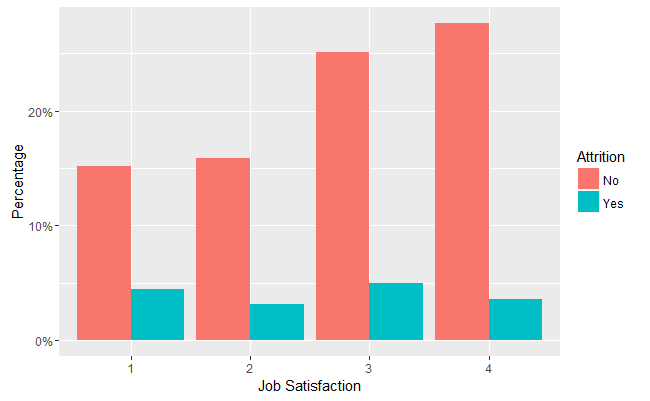

```r
ggplot(df, aes(JobSatisfaction, fill=Attrition)) +
  geom_bar(aes(y=(..count..)/sum(..count..)), position="dodge") +
  scale_y_continuous(labels=percent) +
  xlab("Job Satisfaction") +
  ylab("Percentage")
```

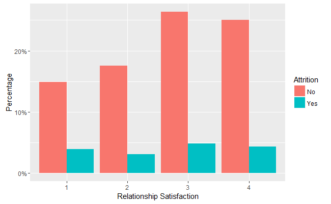

```r
ggplot(df, aes(RelationshipSatisfaction, fill=Attrition)) +
  geom_bar(aes(y=(..count..)/sum(..count..)), position="dodge") +
  scale_y_continuous(labels=percent) +
  xlab("Relationship Satisfaction") +
  ylab("Percentage")
```

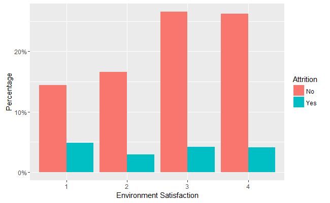

```r
ggplot(df, aes(EnvironmentSatisfaction, fill=Attrition)) +
  geom_bar(aes(y=(..count..)/sum(..count..)), position="dodge") +
  scale_y_continuous(labels=percent) +
  xlab("Environment Satisfaction") +
  ylab("Percentage")
```

It can also be observed from the data set that within the group of churned employees, population of lower satisfaction score is higher.

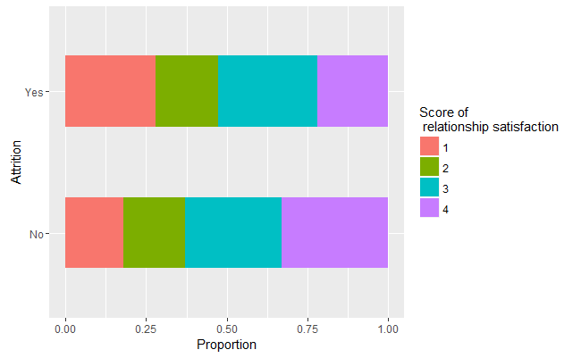

```r
ggplot(df, aes(x=factor(Attrition), fill=factor(JobSatisfaction))) +
  geom_bar(width=0.5, position="fill") +
  coord_flip() +
  xlab("Attrition") +
  ylab("Proportion") +
  scale_fill_discrete(guide=guide_legend(title="Score of\n relationship satisfaction"))
```

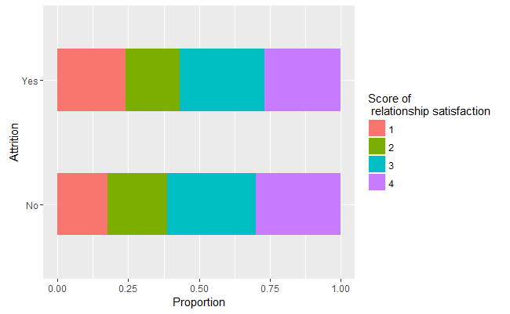

```r
ggplot(df, aes(x=factor(Attrition), fill=factor(RelationshipSatisfaction))) +
  geom_bar(width=0.5, position="fill") +
  coord_flip() +
  xlab("Attrition") +
  ylab("Proportion") +
  scale_fill_discrete(guide=guide_legend(title="Score of\n relationship satisfaction"))
```

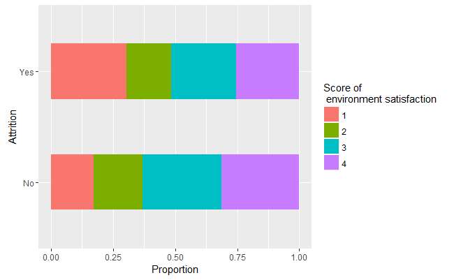

```r
ggplot(df, aes(x=factor(Attrition), fill=factor(EnvironmentSatisfaction))) +
  geom_bar(width=0.5, position="fill") +
  coord_flip() +
  xlab("Attrition") +
  ylab("Proportion") +
  scale_fill_discrete(guide=guide_legend(title="Score of\n environment satisfaction"))
```